# Machine Learning with Python

## Explanation of the `gradientDescent` Function

The `gradientDescent` function implements the gradient descent algorithm to optimize a linear regression model.

### Inputs:

- `X`: Matrix of input features (independent variables).
- `y`: Vector of target values (dependent variable).
- `W`: Initial weights for the linear regression model.
- `alpha`: Learning rate, controlling the step size in gradient descent.
- `iters`: Number of iterations (how many times the weights will be updated).

### Output:

- Returns the optimized weights (`W`) and an array (`cost`) containing the history of cost function values over the iterations.

```python
alpha = 0.01
iters = 10
```

```python
final_x, cost = gradientDescent(A, b, x, alpha, iters)
```

```python
final_x
```

```
matrix([[1.06598171, 0.8       ]])
```

```python
computeCost(A, x, final_x)
```

```
39.479484964851835
```

```python
cost
```

```
array([47.7781    , 45.88078911, 44.27983969, 42.9495556 , 41.86654902,
       41.00953694, 40.35915539, 39.89779004, 39.60942162, 39.47948496])
```

# Let us apply to one large data and see!

```python
!pip install pandas
```

### implementing linear regression with one variable to predict profits for a food truck.

```python
import numpy as np
import pandas as pd
import matplotlib.pyplot as plt
%matplotlib inline
```

```python
data = pd.read_csv('inputs/linear_Reg_1.csv', header=None, names=['Population', 'Profit'])
data.head()
```

|  | Population | Profit |
| --- | --- | --- |
| 0 | 6.1101 | 17.5920 |
| 1 | 5.5277 | 9.1302 |
| 2 | 8.5186 | 13.6620 |
| 3 | 7.0032 | 11.8540 |
| 4 | 5.8598 | 6.8233 |

```python
data.shape
```

```
(97, 2)
```

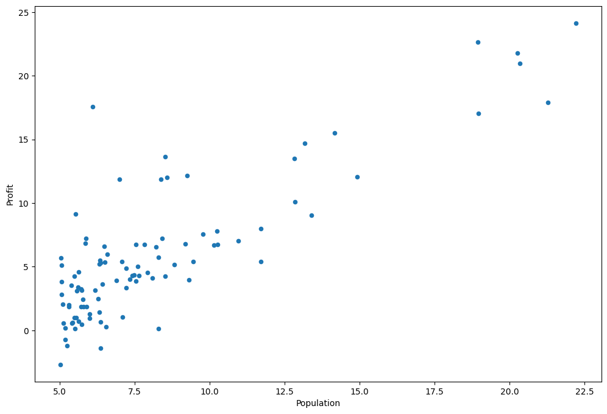

```python
data.plot(kind='scatter', x='Population', y='Profit', figsize=(12,8))
```

```python
# data.insert(0, 'Ones', 1)
cols = data.shape[1]
A = data.iloc[:,0:cols-1]
b = data.iloc[:,cols-1:cols]
```

```python
A.head() # What are the features
```

|  | Population |
| --- | --- |
| 0 | 6.1101 |
| 1 | 5.5277 |
| 2 | 8.5186 |
| 3 | 7.0032 |
| 4 | 5.8598 |

```python
b.head() # What are the labels
```

|  | Profit |
| --- | --- |
| 0 | 17.5920 |
| 1 | 9.1302 |
| 2 | 13.6620 |
| 3 | 11.8540 |
| 4 | 6.8233 |

```python
A = np.matrix(A.values)
b = np.matrix(b.values)
x = np.matrix(np.zeros((A.shape[1], 1)))
```

```python
x
```

```
matrix([[0.]])
```

```python
A.shape, b.shape, x.shape
```

```
((97, 1), (97, 1), (1, 1))
```

```python
computeCost(A, b, x)
```

```
64.14546775491135
```

```python
alpha = 0.01
iters = 1000
```

```python
final_x, cost = gradientDescent(A, b, x, alpha, iters)
print(final_x)
```

```
[[0.80252685]]
```